# STA 141A: Assignment 3

```r
print(wide_dataset_female)
```

```
## # A tibble: 138 × 598
##     year Aaliyah     Abby Abigail     Ada Adaline Adalyn Adalynn Addilyn Addison
##    <dbl>   <dbl>    <dbl>   <dbl>   <dbl>   <dbl>  <dbl>   <dbl>   <dbl>   <dbl>
##  1  1880       0  6.15e-5 1.23e-4 0.00668 2.36e-4      0       0       0       0
##  2  1881       0  7.08e-5 8.09e-5 0.00635 1.82e-4      0       0       0       0
##  3  1882       0  9.51e-5 1.21e-4 0.00596 1.38e-4      0       0       0       0
##  4  1883       0  0       9.16e-5 0.00648 9.16e-5      0       0       0       0
##  5  1884       0  4.36e-5 9.45e-5 0.00621 1.45e-4      0       0       0       0
##  6  1885       0  3.52e-5 6.34e-5 0.00617 1.34e-4      0       0       0       0
##  7  1886       0  4.55e-5 9.76e-5 0.00595 1.24e-4      0       0       0       0
##  8  1887       0  3.22e-5 8.36e-5 0.00586 1.42e-4      0       0       0       0
##  9  1888       0  4.75e-5 9.50e-5 0.00589 8.45e-5      0       0       0       0
## 10  1889       0  4.23e-5 1.06e-4 0.00531 8.46e-5      0       0       0       0
## # ℹ 128 more rows
## # ℹ 588 more variables: Addyson <dbl>, Adelaide <dbl>, Adelina <dbl>,
## #   Adeline <dbl>, Adelyn <dbl>, Adelynn <dbl>, Adriana <dbl>, Adrianna <dbl>,
## #   Ainsley <dbl>, Aisha <dbl>, Alaina <dbl>, Alana <dbl>, Alani <dbl>,
## #   Alanna <dbl>, Alayah <dbl>, Alayna <dbl>, Aleah <dbl>, Aleena <dbl>,
## #   Alejandra <dbl>, Alessandra <dbl>, Alexa <dbl>, Alexandra <dbl>,
## #   Alexandria <dbl>, Alexia <dbl>, Alexis <dbl>, Alice <dbl>, Alicia <dbl>, …
```

10. Apply PCA on the data set for female created in Part 9.

```r
#Obtained from ChatGPT
# Assuming you have the female_dataset from Part 9
# Load required library
library(stats)

# Select only the columns containing proportions (excluding 'year' column)
female_data_for_pca <- wide_dataset_female %>%
  select(-year)

# Apply PCA
pca_result <- prcomp(female_data_for_pca, scale. = TRUE)

# Extract principal components
principal_components <- pca_result$x

# Display summary of PCA
summary(pca_result)
```

```
## Importance of components:
##                            PC1     PC2     PC3     PC4     PC5     PC6     PC7
## Standard deviation     18.3971 10.3757 7.40725 5.49662 4.32375 3.46092 2.83516
## Proportion of Variance  0.5669  0.1803 0.09191 0.05061 0.03131 0.02006 0.01346
## Cumulative Proportion   0.5669  0.7472 0.83915 0.88976 0.92107 0.94114 0.95460
##                            PC8     PC9    PC10   PC11    PC12    PC13    PC14
## Standard deviation     2.27487 1.88960 1.59530 1.3812 1.22865 1.14354 1.02296
## Proportion of Variance 0.00867 0.00598 0.00426 0.0032 0.00253 0.00219 0.00175
## Cumulative Proportion  0.96327 0.96925 0.97351 0.9767 0.97924 0.98143 0.98318
##                           PC15    PC16    PC17    PC18    PC19    PC20    PC21
## Standard deviation     0.92388 0.87205 0.78696 0.73534 0.72084 0.65724 0.61887
## Proportion of Variance 0.00143 0.00127 0.00104 0.00091 0.00087 0.00072 0.00064
## Cumulative Proportion  0.98461 0.98588 0.98692 0.98783 0.98870 0.98942 0.99006
##                           PC22    PC23    PC24    PC25    PC26    PC27    PC28
## Standard deviation     0.59210 0.58154 0.54298 0.53625 0.52365 0.50671 0.49476
## Proportion of Variance 0.00059 0.00057 0.00049 0.00048 0.00046 0.00043 0.00041
## Cumulative Proportion  0.99065 0.99122 0.99171 0.99219 0.99265 0.99308 0.99349
##                           PC29   PC30    PC31    PC32    PC33    PC34    PC35
## Standard deviation     0.47483 0.4204 0.40402 0.39553 0.38969 0.36353 0.35926
## Proportion of Variance 0.00038 0.0003 0.00027 0.00026 0.00025 0.00022 0.00022
## Cumulative Proportion  0.99387 0.9942 0.99444 0.99470 0.99496 0.99518 0.99539
##                           PC36   PC37    PC38    PC39    PC40    PC41    PC42
## Standard deviation     0.35202 0.3469 0.33350 0.33005 0.31049 0.30098 0.29334
## Proportion of Variance 0.00021 0.0002 0.00019 0.00018 0.00016 0.00015 0.00014
## Cumulative Proportion  0.99560 0.9958 0.99599 0.99617 0.99633 0.99648 0.99663
##                           PC43    PC44    PC45    PC46    PC47    PC48    PC49
## Standard deviation     0.29105 0.28977 0.28344 0.27618 0.26997 0.26684 0.26453
## Proportion of Variance 0.00014 0.00014 0.00013 0.00013 0.00012 0.00012 0.00012
## Cumulative Proportion  0.99677 0.99691 0.99705 0.99717 0.99730 0.99741 0.99753
##                           PC50   PC51   PC52    PC53    PC54    PC55    PC56
## Standard deviation     0.25584 0.2456 0.2398 0.23541 0.22761 0.22040 0.21901
## Proportion of Variance 0.00011 0.0001 0.0001 0.00009 0.00009 0.00008 0.00008
## Cumulative Proportion  0.99764 0.9977 0.9978 0.99793 0.99802 0.99810 0.99818
##                           PC57    PC58    PC59    PC60    PC61    PC62    PC63
## Standard deviation     0.21257 0.20828 0.20353 0.20088 0.19983 0.19194 0.18632
## Proportion of Variance 0.00008 0.00007 0.00007 0.00007 0.00007 0.00006 0.00006
## Cumulative Proportion  0.99826 0.99833 0.99840 0.99847 0.99853 0.99859 0.99865
##                           PC64    PC65    PC66    PC67    PC68    PC69    PC70
## Standard deviation     0.18522 0.17927 0.17508 0.17439 0.17389 0.16803 0.16489
## Proportion of Variance 0.00006 0.00005 0.00005 0.00005 0.00005 0.00005 0.00005
```

[output cut: 26 more lines]

```
## Standard deviation     0.06233 0.05981 0.05900 0.05815 0.05642 0.05443 0.05295
## Proportion of Variance 0.00001 0.00001 0.00001 0.00001 0.00001 0.00000 0.00000
## Cumulative Proportion  0.99992 0.99992 0.99993 0.99993 0.99994 0.99995 0.99995
##                          PC120   PC121   PC122   PC123   PC124   PC125   PC126
## Standard deviation     0.05161 0.05137 0.04882 0.04716 0.04652 0.04459 0.04368
## Proportion of Variance 0.00000 0.00000 0.00000 0.00000 0.00000 0.00000 0.00000
## Cumulative Proportion  0.99995 0.99996 0.99996 0.99997 0.99997 0.99997 0.99998
##                          PC127   PC128   PC129   PC130   PC131   PC132   PC133
## Standard deviation     0.04295 0.04033 0.04022 0.03911 0.03688 0.03494 0.03411
## Proportion of Variance 0.00000 0.00000 0.00000 0.00000 0.00000 0.00000 0.00000
## Cumulative Proportion  0.99998 0.99998 0.99999 0.99999 0.99999 0.99999 0.99999
##                          PC134  PC135  PC136   PC137    PC138
## Standard deviation     0.03306 0.0316 0.0294 0.02688 8.17e-15
## Proportion of Variance 0.00000 0.0000 0.0000 0.00000 0.00e+00
## Cumulative Proportion  1.00000 1.0000 1.0000 1.00000 1.00e+00
```

11. How many PCs would you choose to capture this data? Can you offer any insights into the PCs?

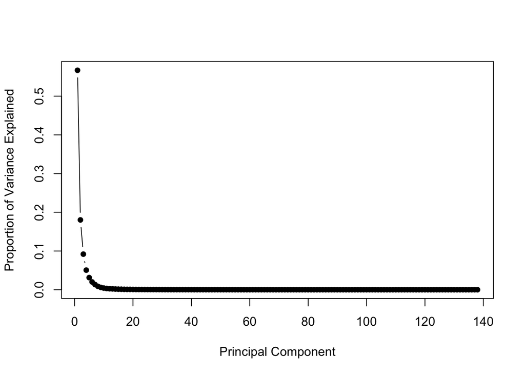

```r
#Obtained from ChatGPT

# Plot the scree plot
plot(1:length(pca_result$sdev), pca_result$sdev^2 / sum(pca_result$sdev^2),
     type = "b", pch = 16, xlab = "Principal Component", ylab = "Proportion of Variance Explained")
```

```r
# Extract eigenvalues from PCA result
eigenvalues <- pca_result$sdev^2

# Count the number of eigenvalues greater than 1
num_components <- sum(eigenvalues > 1)

# Print the number of principal components according to the Kaiser criterion
cat("Number of principal components according to Kaiser criterion:", num_components, "\n")
```

```
## Number of principal components according to Kaiser criterion: 14
```

From ChatGPT: The Kaiser Criterion suggests retaining PCs with eigenvalues greater than 1. Retaining PCs with eigenvalues greater than 1 means each retained PC explains more variance than an individual original variable.

12. Visualize how the coefficients of the top five PCs change over years on the female data set. Discuss your findings.

[figure not shown]

```r
#Obtained from ChatGPT

# Extract the top five PCs
top_five_pcs <- pca_result$rotation[, 1:5]

# Create a dataframe for visualization
unique_years <- unique(dataset_female$year)
common_years <- intersect(unique_years, rownames(top_five_pcs))

coefficients_df <- data.frame(year = common_years, top_five_pcs[common_years, ])

# Melt the dataframe for easy plotting
library(reshape2)
coefficients_melted <- melt(coefficients_df, id.vars = "year", variable.name = "PC", value.name = "Coefficient")

# Plot the coefficients
library(ggplot2)
ggplot(coefficients_melted, aes(x = year, y = Coefficient, color = PC, group = PC)) +
  geom_line() +
  labs(title = "Change in Coefficients of Top 5 PCs Over Years (Female Dataset)",
       x = "Year",
       y = "Coefficient",
       color = "PC") +
  theme_minimal()
```

## Acknowledgement

Failing to acknowledge any non-original efforts will be counted as plagiarism. This incidence will be reported to the Student Judicial Affairs.

If you use generative AI to solve any questions, please provide your instructions, conversations, and prompts here.

```
Briefly summarize the `penguins` data set. In addition to basic description of the dataset (sample size, variables, background), please be sure to read the background of this data set and provide proper citation to this data set.
ChatGPT
The penguins dataset is a popular dataset in the field of data science and is often used for educational purposes. It consists of data related to three species of penguins: Adélie, Chinstrap, and Gentoo. The dataset contains various physical measurements of penguins, such as bill length, bill depth, flipper length, and body mass. These measurements are used to distinguish between the different penguin species.

The background of this dataset is that it was collected by Dr. Kristen Gorman and the Palmer Station, Antarctica LTER, a Long Term Ecological Research program funded by the National Science Foundation. The data was first made available on GitHub by Allison Horst and was later included in the palmerpenguins R package.

Here's a brief summary of the penguins dataset:

Sample size: 344 observations
Variables:
Species (factor with levels Adelie, Chinstrap, and Gentoo)
Island (factor with levels Biscoe, Dream, and Torgersen)
Culmen Length (numeric, in mm)
Culmen Depth (numeric, in mm)
Flipper Length (numeric, in mm)
Body Mass (numeric, in grams)
Sex (factor with levels female, male)
Delta 15 N (numeric)
Delta 13 C (numeric)
Citation:

Gorman, Kristen B.; Williams, Tony D.; Fraser, William R. (2014). Ecological Sexual Dimorphism and Environmental Variability within a Community of Antarctic Penguins (Genus Pygoscelis). PLOS ONE. doi:10.1371/journal.pone.0085297

User
in R
ChatGPT
Sure! Here's how you can load and summarize the penguins dataset in R using the palmerpenguins package:

R
Copy code
# Install and load the palmerpenguins package
install.packages("palmerpenguins")
library(palmerpenguins)

# Load the penguins dataset
data("penguins")

# Display the structure of the dataset
str(penguins)

# Summary statistics of the dataset
summary(penguins)

# Display the first few rows of the dataset
head(penguins)
This code will install the palmerpenguins package if you haven't already installed it, then load the package and the penguins dataset. It will display the structure of the dataset, summary statistics such as mean, median, min, max, and quartiles for numeric variables, and the first few rows of the dataset.

User
Create a data set with no missing values in `bill_length_mm` and `body_mass_g`. Then, create a scatterplot of `body_mass_g` v.s. `bill_length_mm`, where the observations are colored by their true species.
ChatGPT
To create a dataset with no missing values in bill_length_mm and body_mass_g, and then create a scatterplot colored by species, you can use the following code:

R
Copy code
# Load required libraries
library(palmerpenguins)
library(ggplot2)

# Load the penguins dataset
data("penguins")

# Remove rows with missing values in bill_length_mm and body_mass_g
penguins_clean <- penguins[complete.cases(penguins[c("bill_length_mm", "body_mass_g")]), ]

# Create scatterplot colored by species
ggplot(penguins_clean, aes(x = bill_length_mm, y = body_mass_g, color = species)) +
  geom_point() +
  labs(x = "Bill Length (mm)", y = "Body Mass (g)", color = "Species")
This code will first load the required libraries palmerpenguins and ggplot2. Then, it will load the penguins dataset. After that, it removes rows with missing values in bill_length_mm and body_mass_g using complete.cases(). Finally, it creates a scatterplot using ggplot() where x is bill_length_mm, y is body_mass_g, and the points are colored by the species variable.

User
Given the code, spec.cluster<-penguins.narm %>% select(bill_length_mm, body_mass_g) %>% as.matrix() %>% specc(centers=3),

Apply spectral clustering using the `specc()` function in package `kernlab` using the provided code.  Visualize the clusters in a scatterplot.
ChatGPT
Sure, here's how you can apply spectral clustering using the specc() function from the kernlab package and visualize the clusters in a scatterplot:

R
Copy code
# Load required libraries
library(palmerpenguins)
library(kernlab)
library(ggplot2)

# Load the penguins dataset
data("penguins")

# Remove rows with missing values in bill_length_mm and body_mass_g
penguins_narm <- na.omit(penguins[, c("bill_length_mm", "body_mass_g")])

# Select the variables of interest and convert to matrix
penguins_matrix <- as.matrix(penguins_narm)

# Apply spectral clustering
spec_cluster <- specc(penguins_matrix, centers = 3)

# Add cluster labels to the dataset
penguins_narm$cluster <- as.factor(spec_cluster)

# Visualize the clusters in a scatterplot
ggplot(penguins_narm, aes(x = bill_length_mm, y = body_mass_g, color = cluster)) +
  geom_point() +
  labs(x = "Bill Length (mm)", y = "Body Mass (g)", color = "Cluster")
This code first loads the required libraries palmerpenguins, kernlab, and ggplot2. Then, it loads the penguins dataset and removes rows with missing values in bill_length_mm and body_mass_g. Next, it selects the variables of interest and converts them to a matrix. Spectral clustering is applied using the specc() function with the desired number of centers (in this case, 3). Cluster labels are added to the dataset, and finally, the clusters are visualized in a scatterplot where points are colored by their cluster membership.

User
spec.cluster<-penguins.narm %>% select(bill_length_mm, body_mass_g) %>% as.matrix() %>% specc(centers=3)
ChatGPT
It seems there was a slight issue in the provided code. Let's correct it. Here's the revised code:

R
Copy code
# Load required libraries
library(palmerpenguins)
library(kernlab)

# Load the penguins dataset
data("penguins")

# Remove rows with missing values in bill_length_mm and body_mass_g
penguins_narm <- na.omit(penguins[, c("bill_length_mm", "body_mass_g")])

# Select the variables of interest and convert to matrix
penguins_matrix <- as.matrix(penguins_narm)

# Apply spectral clustering
spec_cluster <- specc(penguins_matrix, centers = 3)
```

[output not shown]

```
# Standardize the variables
penguins_scaled <- penguins_narm %>%
  select(bill_length_mm, body_mass_g) %>%
  scale()

# Apply spectral clustering on the standardized data
spec_cluster_scaled <- specc(penguins_scaled, centers = 3)

# Add cluster labels to the original dataset
penguins_narm$cluster <- as.factor(spec_cluster_scaled)

# Visualize the clusters in a scatterplot
ggplot(penguins_narm, aes(x = bill_length_mm, y = body_mass_g, color = cluster)) +
  geom_point() +
  labs(x = "Standardized Bill Length (mm)", y = "Standardized Body Mass (g)", color = "Cluster")
ChatGPT
To modify the code to obtain 5 and 8 clusters using spectral clustering, you can simply change the centers parameter in the specc() function to the desired number of clusters. Here's the modified code:

R
Copy code
# Load required libraries
library(palmerpenguins)
library(dplyr)
library(ggplot2)
library(kernlab)  # Ensure kernlab is loaded for the specc() function

# Load the penguins dataset
data("penguins")

# Remove rows with missing values in bill_length_mm and body_mass_g
penguins_narm <- na.omit(penguins[, c("bill_length_mm", "body_mass_g")])

# Standardize the variables
penguins_scaled <- penguins_narm %>%
  select(bill_length_mm, body_mass_g) %>%
  scale()

# Apply spectral clustering on the standardized data with 5 clusters
spec_cluster_scaled_5 <- specc(penguins_scaled, centers = 5)

# Add cluster labels to the original dataset
penguins_narm$cluster_5 <- as.factor(spec_cluster_scaled_5)

# Visualize the clusters in a scatterplot for 5 clusters
ggplot(penguins_narm, aes(x = bill_length_mm, y = body_mass_g, color = cluster_5)) +
  geom_point() +
  labs(x = "Standardized Bill Length (mm)", y = "Standardized Body Mass (g)", color = "Cluster (5)")

# Apply spectral clustering on the standardized data with 8 clusters
spec_cluster_scaled_8 <- specc(penguins_scaled, centers = 8)

# Add cluster labels to the original dataset
penguins_narm$cluster_8 <- as.factor(spec_cluster_scaled_8)

# Visualize the clusters in a scatterplot for 8 clusters
ggplot(penguins_narm, aes(x = bill_length_mm, y = body_mass_g, color = cluster_8)) +
  geom_point() +
  labs(x = "Standardized Bill Length (mm)", y = "Standardized Body Mass (g)", color = "Cluster (8)")
This code first applies spectral clustering on the standardized data with 5 clusters and then with 8 clusters using the specc() function. It then adds cluster labels to the original dataset and visualizes the clusters in separate scatterplots for 5 and 8 clusters.

User
how do i interpret/compare the cluster plots
ChatGPT
Interpreting and comparing cluster plots involves understanding the distribution of data points across clusters and assessing how well the clustering algorithm has separated the data into distinct groups. Here's how you can interpret and compare the cluster plots:

Number of Clusters: When comparing cluster plots, first consider the number of clusters generated by the algorithm. In your case, you have generated cluster plots for 5 and 8 clusters, respectively.

Cluster Separation: Look for clear separation between clusters in the plots. Ideally, data points within a cluster should be close to each other and well-separated from data points in other clusters. If clusters overlap significantly, it may indicate that the algorithm is not effectively separating the data.

Cluster Size: Check the size of each cluster. Balanced cluster sizes suggest that the algorithm has successfully grouped the data points into meaningful clusters. Highly imbalanced cluster sizes may indicate that the algorithm is biased towards certain clusters or that some clusters represent outliers or noise.

Cluster Centers: If the clustering algorithm provides cluster centers, you can inspect these to understand the centroids of each cluster in the feature space. This can help you interpret the characteristics of each cluster.

Cluster Density: Consider the density of data points within each cluster. Denser clusters indicate that the data points within that cluster are more similar to each other, while sparser clusters may have more variability.

Cluster Labels: If your data has ground truth labels (i.e., true species labels in the case of the penguins dataset), you can compare the cluster assignments generated by the algorithm with the true labels. Assess the correspondence between clusters and true groups to evaluate the performance of the clustering algorithm.

Overall, when comparing cluster plots, you're looking for clear separation between clusters, balanced cluster sizes, and meaningful groupings of data points that align with the underlying structure of your data. Additionally, it's important to consider the specific context of your analysis and whether the clusters obtained make sense in that context.

Briefly summarize the `babynames` data set in R. In particular, what does each row represents?
ChatGPT
The babynames data set in R typically contains information about the frequency of baby names given to newborns in the United States over the years. Each row represents a unique combination of a baby name, its gender, and the number of occurrences of that name in a specific year. The data set usually includes columns such as "name," "sex" (gender), "year," and "count" (the number of occurrences of the name in that year). This data set is often used for analyzing trends in baby names over time and exploring cultural preferences in naming practices.

User
Briefly summarize the `babynames` data set in R
ChatGPT
The babynames dataset in R is a collection of records detailing the frequency of given baby names in the United States over several decades. It typically includes columns such as "name", "sex" (gender), "year", and "count" (the number of occurrences of each name in a specific year). This dataset allows for the analysis of naming trends over time, gender-based naming preferences, and the popularity of specific names across different years. It's commonly used in statistical analysis and data visualization projects.
```

[output not shown]

```
User
Extract names used by no fewer than 500 babies in 2017 for each sex.  ^code above
ChatGPT
Certainly! Below is the corrected code to extract names used by no fewer than 500 babies in 2017 for each sex:

r
Copy code
library(dplyr)

# Load the babynames dataset
data("babynames")

# Filter names for 2017 and count greater than or equal to 500 for each sex
filtered_names_male <- babynames %>%
  filter(year == 2017, sex == "M", count >= 500)

filtered_names_female <- babynames %>%
  filter(year == 2017, sex == "F", count >= 500)

# Display the result
print(filtered_names_male)
print(filtered_names_female)
This code filters the babynames dataset for the year 2017 and counts greater than or equal to 500, separately for males and females, using the dplyr package. Let me know if you need further assistance!

User
Create two new datasets where each row corresponds to one year and each column corresponds to the `prop` of a name in the list of names selected in Part 8, one per sex.
ChatGPT
To create two new datasets where each row corresponds to one year and each column corresponds to the proportion (prop) of a name in the list of names selected in Part 8, one for each sex, you can use the following code:

r
Copy code
library(dplyr)
library(tidyr)

# Load the babynames dataset
data("babynames")

# Filter names used by no fewer than 500 babies in 2017 for each sex
filtered_names_male <- babynames %>%
  filter(year == 2017, sex == "M", count >= 500)

filtered_names_female <- babynames %>%
  filter(year == 2017, sex == "F", count >= 500)

# Extract unique names for each sex
unique_names_male <- unique(filtered_names_male$name)
unique_names_female <- unique(filtered_names_female$name)

# Filter original dataset for the years of interest
filtered_dataset <- babynames %>%
  filter(year >= min(filtered_names_male$year, na.rm = TRUE),
         year <= max(filtered_names_male$year, na.rm = TRUE))

# Create datasets for male and female
male_dataset <- filtered_dataset %>%
  filter(sex == "M") %>%
  group_by(year) %>%
  mutate(prop = count / sum(count)) %>%
  filter(name %in% unique_names_male) %>%
  ungroup() %>%
  select(year, name, prop) %>%
  spread(name, prop, fill = 0)

female_dataset <- filtered_dataset %>%
  filter(sex == "F") %>%
  group_by(year) %>%
  mutate(prop = count / sum(count)) %>%
  filter(name %in% unique_names_female) %>%
  ungroup() %>%
  select(year, name, prop) %>%
  spread(name, prop, fill = 0)

# Display the datasets
head(male_dataset)
head(female_dataset)
This code will create two datasets, male_dataset and female_dataset, where each row corresponds to one year and each column corresponds to the proportion (prop) of a name in the list of names selected in Part 8 for males and females, respectively. Adjustments might be needed depending on the specifics of your data. Let me know if you need further assistance!


1 / 2

User
Apply PCA on the data set for female created in Part 9.
ChatGPT
To apply Principal Component Analysis (PCA) on the dataset for females created in Part 9, you can use the prcomp function in R. Here's an example code snippet:

r
Copy code
# Assuming you have the female_dataset from Part 9

# Load required library
library(stats)

# Select only the columns containing proportions (excluding 'year' column)
female_data_for_pca <- female_dataset %>%
  select(-year)

# Apply PCA
pca_result <- prcomp(female_data_for_pca, scale. = TRUE)

# Extract principal components
principal_components <- pca_result$x

# Display summary of PCA
summary(pca_result)

# Plot the scree plot to visualize variance explained by each principal component
plot(1:length(pca_result$sdev), pca_result$sdev^2 / sum(pca_result$sdev^2),
     type = "b", pch = 16, xlab = "Principal Component", ylab = "Proportion of Variance Explained")

# Biplot (you can customize as needed)
biplot(pca_result)
In this code:

prcomp performs PCA on the female dataset, scaling the variables (scale. = TRUE).
pca_result$x contains the principal components.
summary(pca_result) provides information about the variance explained by each principal component.
The scree plot helps visualize the proportion of variance explained by each principal component.
The biplot displays the projection of variables onto the first two principal components.
Please ensure that your female_dataset is in the correct format before running this code. Adjustments may be needed based on the specific structure and content of your data. If you encounter any issues or have further questions, feel free to ask!


2 / 2

User
i am given this code

#Obtained from ChatGPT
filtered_names_male <- babynames %>%
  filter(year == 2017, sex == "M", n <= 500)

filtered_names_female <- babynames %>%
  filter(year == 2017, sex == "F", n <= 500)

# Extract unique names for each sex
unique_names_male <- unique(filtered_names_male$name)
unique_names_female <- unique(filtered_names_female$name)

# Create datasets for each sex
dataset_male <- babynames %>%
  filter(sex == "M", name %in% unique_names_male) %>%
  select(year, name, prop)

dataset_female <- babynames %>%
  filter(sex == "F", name %in% unique_names_female) %>%
  select(year, name, prop)

# Reshape the datasets
wide_dataset_male <- spread(dataset_male, name, prop, fill = 0)
wide_dataset_female <- spread(dataset_female, name, prop, fill = 0)

# Display the results
# print(wide_dataset_male)
# print(wide_dataset_female)
ChatGPT
To apply Principal Component Analysis (PCA) on the wide_dataset_female created in the provided code, you can follow similar steps as in the previous example. Here's how you can do it:

r
Copy code
# Load required library
library(stats)

# Select only the columns containing proportions (excluding 'year' column)
female_data_for_pca <- wide_dataset_female %>%
  select(-year)

# Apply PCA
pca_result <- prcomp(female_data_for_pca, scale. = TRUE)

# Extract principal components
principal_components <- pca_result$x

# Display summary of PCA
summary(pca_result)

# Plot the scree plot to visualize variance explained by each principal component
plot(1:length(pca_result$sdev), pca_result$sdev^2 / sum(pca_result$sdev^2),
     type = "b", pch = 16, xlab = "Principal Component", ylab = "Proportion of Variance Explained")
```

```
# Biplot (you can customize as needed)
biplot(pca_result)
In this code:

prcomp performs PCA on the female dataset, scaling the variables (scale. = TRUE).
pca_result$x contains the principal components.
summary(pca_result) provides information about the variance explained by each principal component.
The scree plot helps visualize the proportion of variance explained by each principal component.
The biplot displays the projection of variables onto the first two principal components.
Please ensure that your wide_dataset_female is in the correct format before running this code. Adjustments may be needed based on the specific structure and content of your data. If you encounter any issues or have further questions, feel free to ask!

User
How many PCs would you choose to capture this data? Can you offer any insights into the PCsHow many PCs would you choose to capture this data? Can you offer any insights into the PCs
ChatGPT
To determine how many principal components (PCs) to choose to capture the data, you typically look at the scree plot. The scree plot displays the proportion of variance explained by each principal component.

Here's how you can interpret the scree plot:

Look for the "elbow" or point where the plot starts to flatten out. This is typically where you should stop adding principal components.
Principal components to the left of the elbow explain a significant amount of variance, while those to the right explain less.
Once you've identified the elbow, you can select the number of principal components that explain a substantial portion of the variance.

Additionally, you can consider using the Kaiser criterion, which suggests retaining principal components with eigenvalues greater than 1.

Here's a summary of possible approaches:

Look for the elbow in the scree plot.
Use the Kaiser criterion.
Choose a predefined number of principal components based on prior knowledge or practical considerations.
If you provide the scree plot or the summary of the PCA results, I can help you interpret them and provide insights into the principal components. Let me know if you need further assistance!

User
Visualize how the coefficients of the top five PCs change over years on the female data set. Discuss your findings.
ChatGPT
To visualize how the coefficients of the top five principal components (PCs) change over years on the female dataset, you can plot the coefficients of these PCs against the years. Here's how you can do it:

r
Copy code
# Extract the top five PCs
top_five_pcs <- pca_result$rotation[, 1:5]

# Create a dataframe for visualization
coefficients_df <- data.frame(year = wide_dataset_female$year, top_five_pcs)

# Melt the dataframe for easy plotting
coefficients_melted <- melt(coefficients_df, id.vars = "year", variable.name = "PC", value.name = "Coefficient")

# Plot the coefficients
library(ggplot2)
ggplot(coefficients_melted, aes(x = year, y = Coefficient, color = PC)) +
  geom_line() +
  labs(title = "Change in Coefficients of Top 5 PCs Over Years (Female Dataset)",
       x = "Year",
       y = "Coefficient",
       color = "PC") +
  theme_minimal()
In this code:

We extract the rotation matrix from the PCA result, containing the coefficients of the top five PCs.
We create a dataframe (coefficients_df) with years and the coefficients of the top five PCs.
We melt the dataframe to convert it into a format suitable for plotting.
We plot the coefficients against the years, with each PC represented by a different color.
Once you've generated the plot, you can analyze the trends in the coefficients of the top five PCs over the years. Look for any patterns or significant changes, which can provide insights into how the variables (names) are associated with each PC over time.

Feel free to adjust the visualization or analysis as needed based on your specific dataset and research questions. Let me know if you need further assistance!


3 / 3

User
melt function install
ChatGPT
My apologies for the oversight. The melt function is actually part of the reshape2 package, not a separate package itself. You just need to install and load the reshape2 package in order to use the melt function. Here's how you can do it:

r
Copy code
# Install and load the reshape2 package
install.packages("reshape2")
library(reshape2)
After installing and loading the package, you should be able to use the melt function as described in the previous code snippet. Let me know if you need further assistance!

User
# Assuming you have the female_dataset from Part 9
# Load required library
library(stats)

# Select only the columns containing proportions (excluding 'year' column)
female_data_for_pca <- wide_dataset_female %>%
  select(-year)

# Apply PCA
pca_result <- prcomp(female_data_for_pca, scale. = TRUE)

# Extract principal components
principal_components <- pca_result$x

# Display summary of PCA
summary(pca_result)
ChatGPT
The provided code snippet applies Principal Component Analysis (PCA) on the female dataset and displays a summary of the PCA results. Here's a breakdown of what each part does:

library(stats): This line loads the stats package, which is a core package in R and contains functions for statistical analysis, including PCA.

female_data_for_pca <- wide_dataset_female %>% select(-year): This line selects all columns from the wide_dataset_female except the "year" column, as PCA is typically applied to numeric variables only.

pca_result <- prcomp(female_data_for_pca, scale. = TRUE): This line applies PCA to the selected data (female_data_for_pca). The scale. = TRUE argument scales the variables to have unit variance before PCA, which is a common practice to ensure variables are comparable.

principal_components <- pca_result$x: This line extracts the principal components from the PCA result. The principal components are the transformed variables that capture the most variance in the original data.

summary(pca_result): This line displays a summary of the PCA results, including the standard deviations of the principal components, the proportion of variance explained by each component, and cumulative proportion of variance explained.
```

```
By examining the summary of the PCA results, you can gain insights into how much variance is captured by each principal component and decide how many principal components to retain based on your analysis goals and the proportion of variance explained.

User
How many PCs would you choose to capture this data? Can you offer any insights into the PCs?
ChatGPT
To determine how many principal components (PCs) to choose to capture the data, you typically examine the scree plot or consider the Kaiser criterion, which suggests retaining PCs with eigenvalues greater than 1.

Scree Plot: The scree plot shows the proportion of variance explained by each principal component. You typically look for an "elbow" in the plot, where the proportion of variance explained by each subsequent PC starts to level off. You might choose to retain the PCs before this elbow.

Kaiser Criterion: This criterion suggests retaining PCs with eigenvalues greater than 1. Eigenvalues represent the amount of variance explained by each PC. Retaining PCs with eigenvalues greater than 1 means each retained PC explains more variance than an individual original variable.

Additionally, you can consider the cumulative proportion of variance explained by the retained PCs. You might aim to retain enough PCs to capture a significant portion of the total variance in the data, such as 70-80%.

Once you've determined the number of PCs to retain, you can interpret each PC to understand the patterns in the data it represents. PC loadings indicate the relationship between the original variables and the PCs. High loadings (positive or negative) suggest strong associations between variables and the corresponding PC.

Here's an example of how you might interpret the first few PCs:

PC1: Represents the most variance in the data. High loadings on certain variables suggest those variables contribute most to the variation captured by PC1.
PC2: Represents additional variance orthogonal to PC1. Variables with high loadings on PC2 but low loadings on PC1 capture unique variance not explained by PC1.
PC3, PC4, ...: Capture progressively smaller amounts of variance, representing finer patterns or noise in the data.
To make a decision on how many PCs to retain for your specific analysis, you'll need to examine the scree plot, consider the Kaiser criterion, and evaluate the cumulative proportion of variance explained. Additionally, domain knowledge and research goals can influence the decision-making process.

User
give me the scree plot code in r
ChatGPT
Certainly! Here's how you can create a scree plot in R using the pca_result object obtained from your PCA analysis:

r
Copy code
# Plot the scree plot
plot(1:length(pca_result$sdev), pca_result$sdev^2 / sum(pca_result$sdev^2),
     type = "b", pch = 16, xlab = "Principal Component", ylab = "Proportion of Variance Explained")
This code will create a scree plot where the x-axis represents the principal components and the y-axis represents the proportion of variance explained by each component. The ^2 / sum(pca_result$sdev^2) part normalizes the variance explained by each component to the total variance explained by all components.

You can use this plot to identify the point (the "elbow") where the proportion of variance explained starts to level off, helping you decide how many principal components to retain. Let me know if you need further assistance!

User
kaiser criterion in r
ChatGPT
To implement the Kaiser criterion in R, you can extract the eigenvalues from the PCA result and identify the number of principal components with eigenvalues greater than 1. Here's how you can do it:

r
Copy code
# Extract eigenvalues from PCA result
eigenvalues <- pca_result$sdev^2

# Count the number of eigenvalues greater than 1
num_components <- sum(eigenvalues > 1)

# Print the number of principal components according to the Kaiser criterion
cat("Number of principal components according to Kaiser criterion:", num_components, "\n")
This code snippet calculates the number of principal components based on the Kaiser criterion by counting the eigenvalues greater than 1. The sdev attribute of the PCA result contains the standard deviations (square roots of the eigenvalues) of the principal components.

You can then use this information to decide how many principal components to retain for your analysis. Let me know if you need further assistance!

User
Visualize how the coefficients of the top five PCs change over years on the female data set.
ChatGPT
To visualize how the coefficients of the top five principal components (PCs) change over years on the female dataset, you can create line plots for each PC, with years on the x-axis and coefficients on the y-axis. Here's how you can do it:

r
Copy code
# Assuming you have the female_dataset from Part 9
# Assuming you have already conducted PCA and obtained pca_result

# Extract the top five PCs
top_five_pcs <- pca_result$rotation[, 1:5]

# Create a dataframe for visualization
coefficients_df <- data.frame(year = wide_dataset_female$year, top_five_pcs)

# Melt the dataframe for easy plotting
coefficients_melted <- melt(coefficients_df, id.vars = "year", variable.name = "PC", value.name = "Coefficient")

# Plot the coefficients
library(ggplot2)
ggplot(coefficients_melted, aes(x = year, y = Coefficient, color = PC)) +
  geom_line() +
  labs(title = "Change in Coefficients of Top 5 PCs Over Years (Female Dataset)",
       x = "Year",
       y = "Coefficient",
       color = "PC") +
  theme_minimal()
In this code:

We extract the rotation matrix from the PCA result, containing the coefficients of the top five PCs.
We create a dataframe (coefficients_df) with years and the coefficients of the top five PCs.
We melt the dataframe to convert it into a format suitable for plotting.
We plot the coefficients against the years, with each PC represented by a different color.
This code will generate a line plot showing how the coefficients of the top five principal components change over the years for the female dataset. You can interpret the trends in these coefficients to understand how the variables (names) are associated with each PC over time. Adjust the plot and analysis as needed based on your specific dataset and research questions. Let me know if you need further assistance!
```

[output not shown]

```
Assuming dataset_female has a different number of rows compared to the top_five_pcs matrix, you should first check the number of unique years in dataset_female and ensure that there is a corresponding row in the top_five_pcs matrix for each unique year. Here's a revised version of the code:

r
Copy code
# Assuming you have the female_dataset from Part 9
# Assuming you have already conducted PCA and obtained pca_result

# Extract the top five PCs
top_five_pcs <- pca_result$rotation[, 1:5]

# Create a dataframe for visualization
unique_years <- unique(female_dataset$year)
common_years <- intersect(unique_years, rownames(top_five_pcs))

coefficients_df <- data.frame(year = common_years, top_five_pcs[common_years, ])

# Melt the dataframe for easy plotting
library(reshape2)
coefficients_melted <- melt(coefficients_df, id.vars = "year", variable.name = "PC", value.name = "Coefficient")

# Plot the coefficients
library(ggplot2)
ggplot(coefficients_melted, aes(x = year, y = Coefficient, color = PC, group = PC)) +
  geom_line() +
  labs(title = "Change in Coefficients of Top 5 PCs Over Years (Female Dataset)",
       x = "Year",
       y = "Coefficient",
       color = "PC") +
  theme_minimal()
In this updated code:

We find the common years that exist in both the dataset_female and the rows of top_five_pcs.
We create a dataframe (coefficients_df) using only the common years and the corresponding rows of top_five_pcs.
Then, we proceed with melting and plotting as before.
This should address the mismatch in the number of rows. Please try this code, and let me know if it resolves the issue.
```